# R Notebook: Workspace Audit for [monte_shaffer]

#### 1.4.3.2 Git Log Graphics

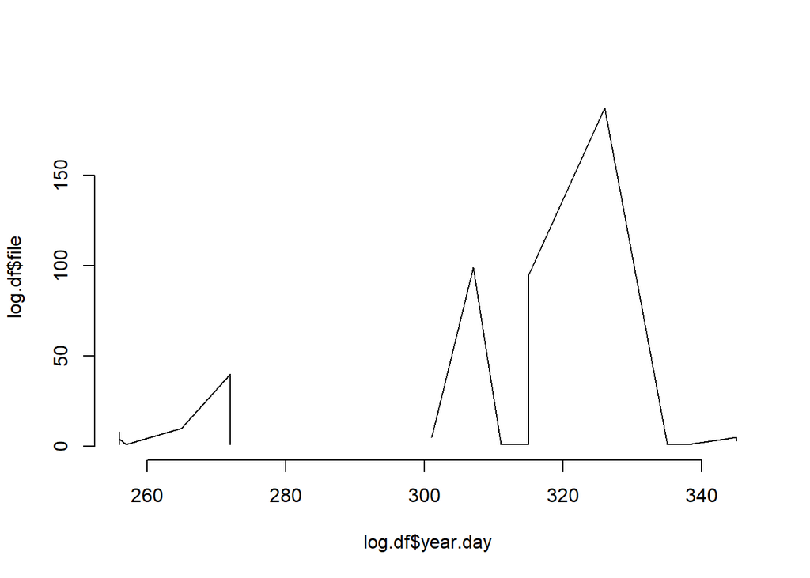

```r
plot(log.df$year.day, log.df$file, bty="n", type="l");
```

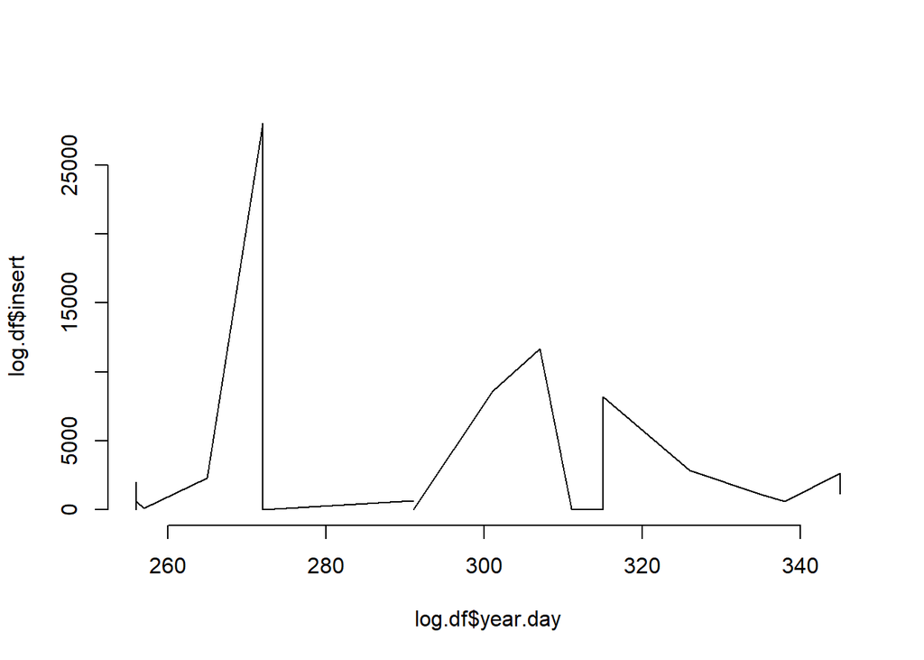

```r
plot(log.df$year.day, log.df$insert, bty="n", type="l");
```

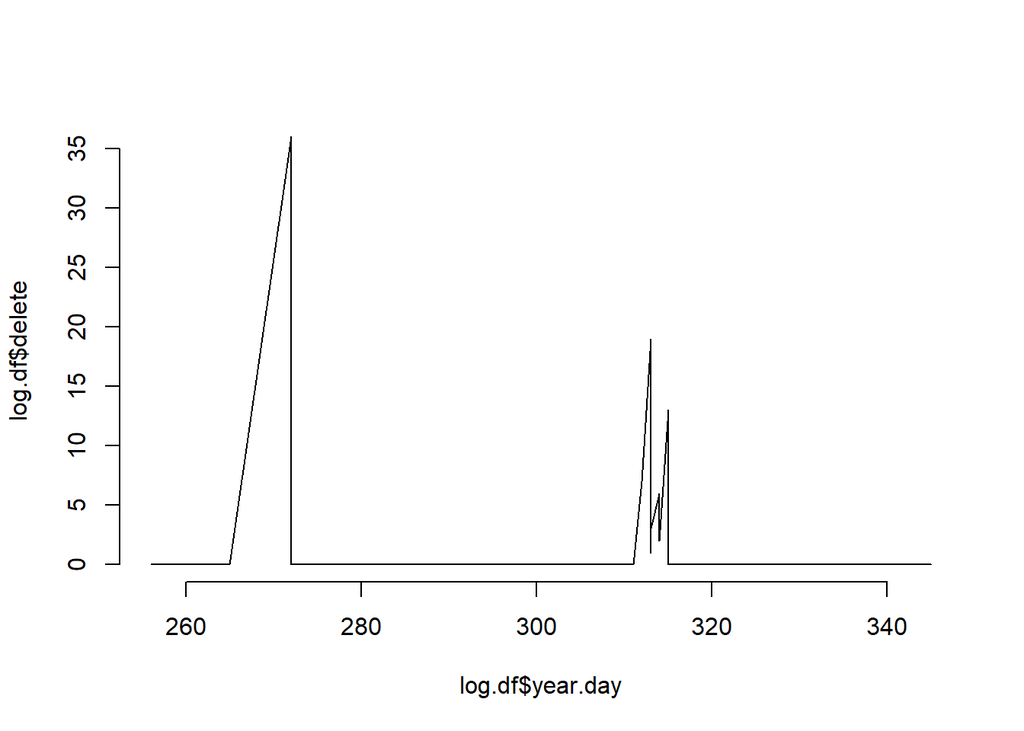

```r
plot(log.df$year.day, log.df$delete, bty="n", type="l");
```

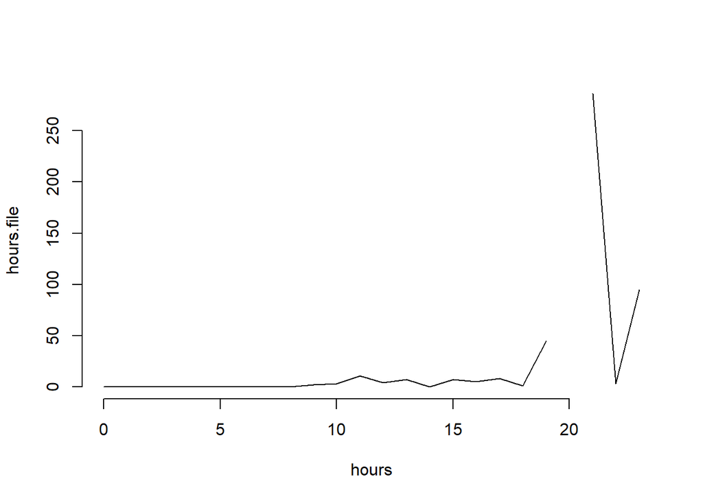

```r
weeks = sort(unique(log.df$year.week));
n.weeks = length(weeks);
weeks.file = weeks.insert = weeks.delete = numeric(n.weeks);

days = 1:7;
n.days = length(days);
days.file = days.insert = days.delete = numeric(n.days);

hours = 0:23;
n.hours = length(hours);
hours.file = hours.insert = hours.delete = numeric(n.hours);

for(i in 1:total.commits)
  {
  my.hour = log.df$day.hour[i];
    idx.hour = which(my.hour == hours)[1];
  my.week = log.df$year.week[i];
    idx.week = which(my.week == weeks)[1];
  my.day = log.df$day.week[i];
    idx.day = which(my.day == days)[1];

  n.file = log.df$file[i];
  n.insert = log.df$insert[i];
  n.delete = log.df$delete[i];

  hours.file[idx.hour]   = hours.file[idx.hour]   + n.file;
  hours.insert[idx.hour] = hours.insert[idx.hour] + n.insert;
  hours.delete[idx.hour] = hours.delete[idx.hour] + n.delete;

  days.file[idx.day]   = days.file[idx.day]   + n.file;
  days.insert[idx.day] = days.insert[idx.day] + n.insert;
  days.delete[idx.day] = days.delete[idx.day] + n.delete;

  weeks.file[idx.week]   = weeks.file[idx.week]   + n.file;
  weeks.insert[idx.week] = weeks.insert[idx.week] + n.insert;
  weeks.delete[idx.week] = weeks.delete[idx.week] + n.delete;
  }


my.git$groups = list();
my.git$groups$hours = list("hours" = hours, "file" = hours.file, "insert" = hours.insert, "delete" = hours.delete);
my.git$groups$days = list("days" = days, "file" = days.file, "insert" = days.insert, "delete" = days.delete);
my.git$groups$weeks = list("weeks" = weeks, "file" = weeks.file, "insert" = weeks.insert, "delete" = weeks.delete);
my.object$git = my.git;

plot(hours, hours.file,   bty="n", type="l");  # 0 is midnight
```

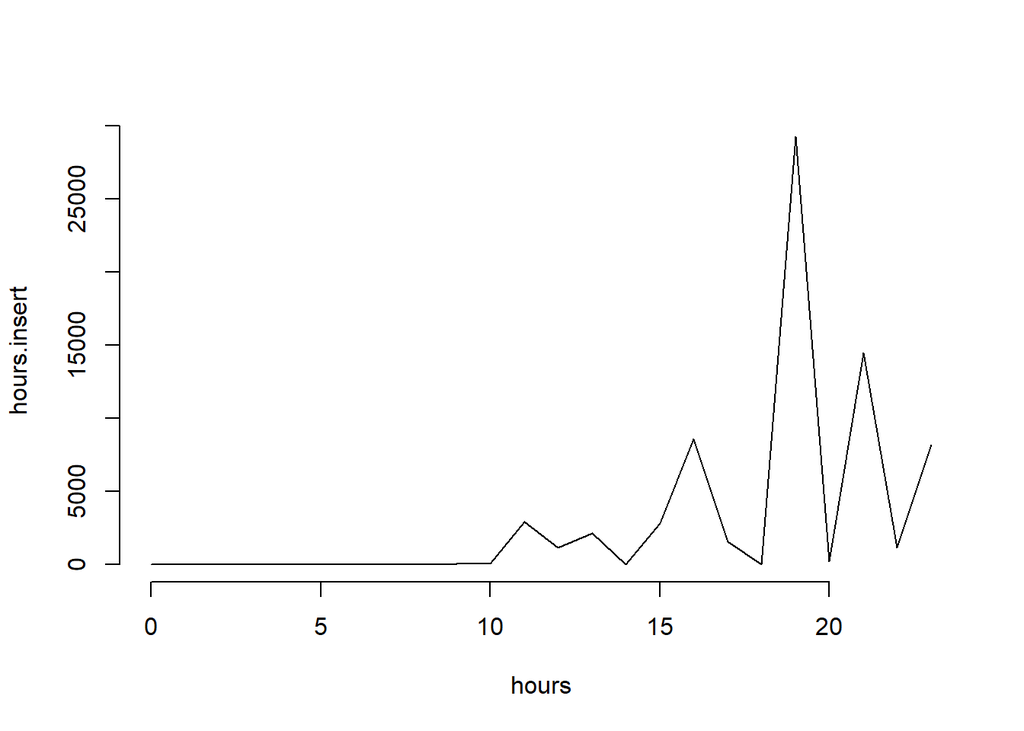

```r
plot(hours, hours.insert, bty="n", type="l");
```

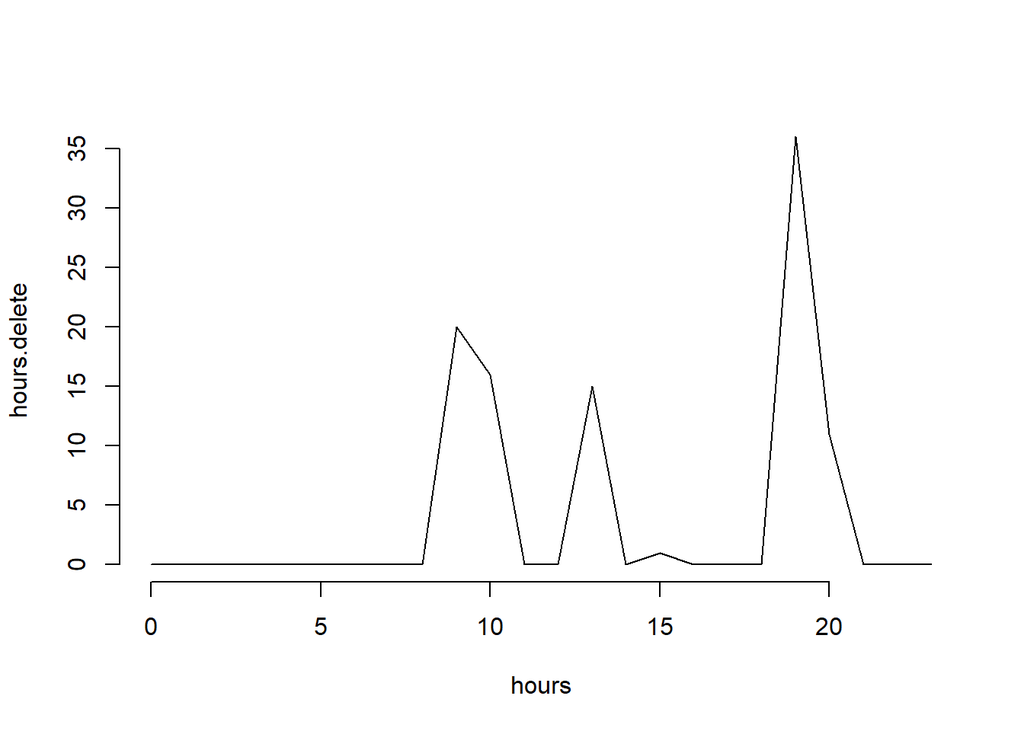

```r
plot(hours, hours.delete, bty="n", type="l");
```

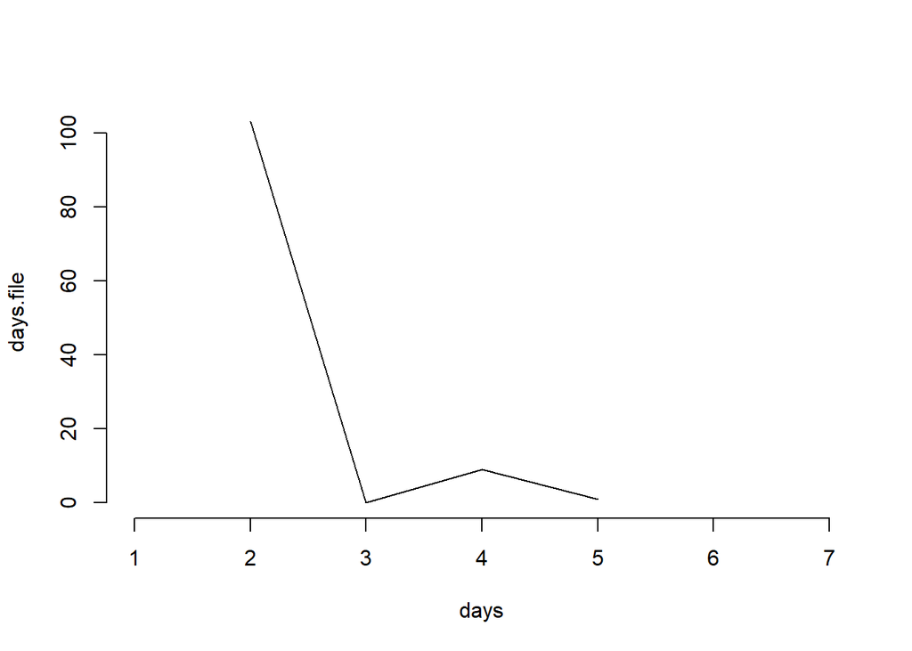

```r
plot(days, days.file,   bty="n", type="l");    # 1 is Monday
```

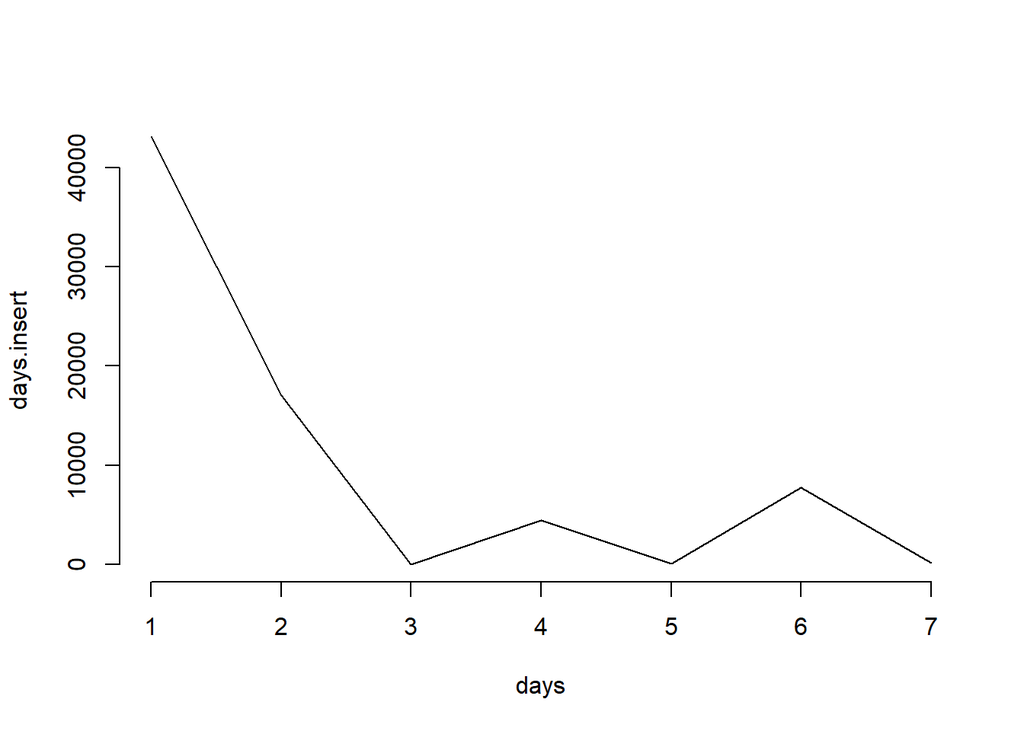

```r
plot(days, days.insert, bty="n", type="l");
```

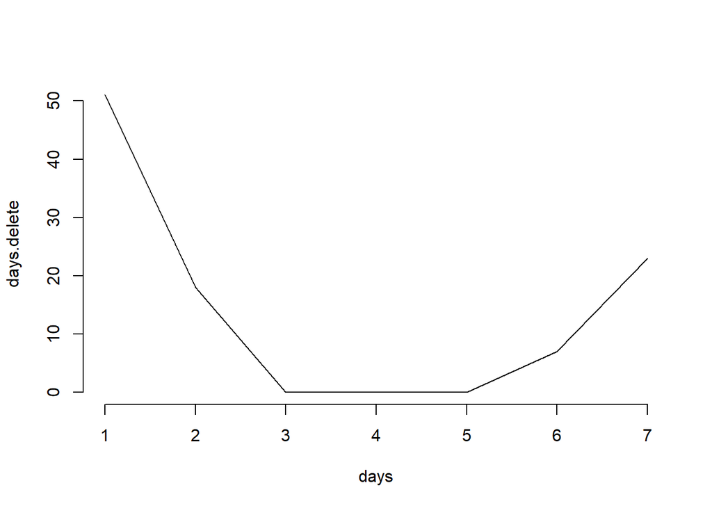

```r
plot(days, days.delete, bty="n", type="l");
```

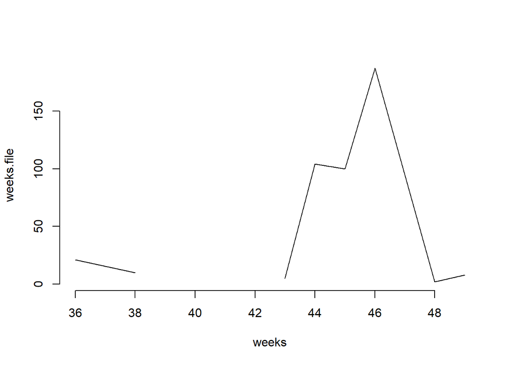

```r
plot(weeks, weeks.file,   bty="n", type="l");  # 36 is August 30, 2020
```

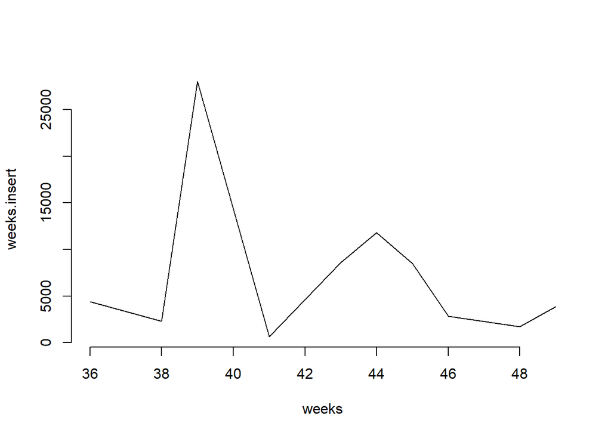

```r
plot(weeks, weeks.insert, bty="n", type="l");  # https://savvytime.com/week-number
```

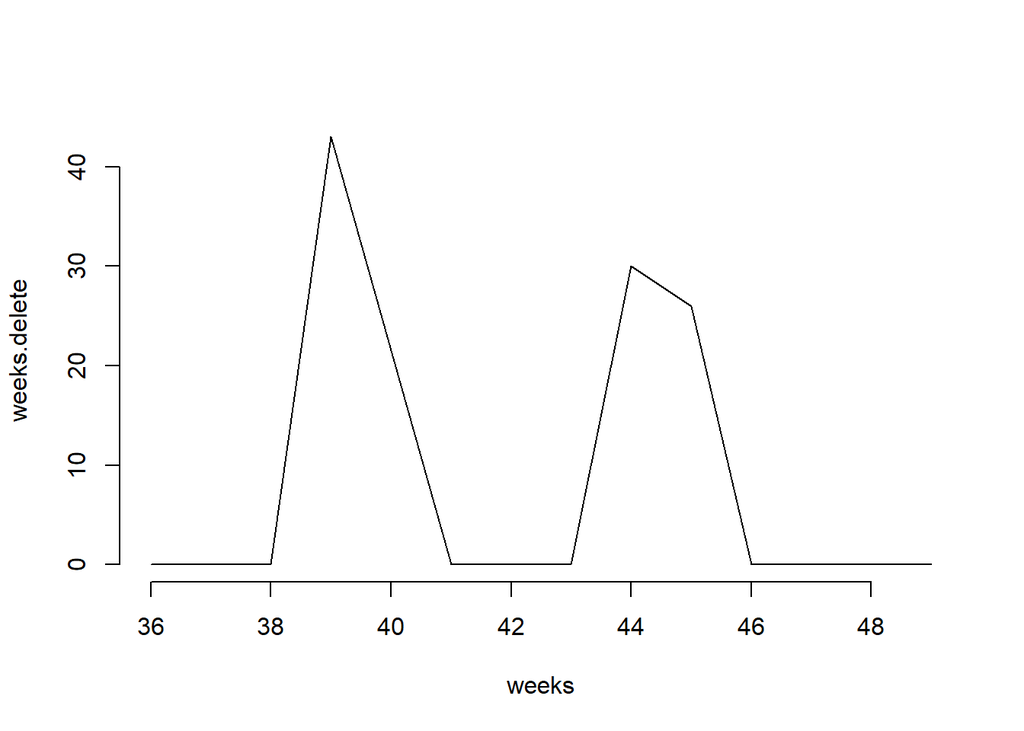

```r
plot(weeks, weeks.delete, bty="n", type="l");
```

```r
###############################################
### Feel free to improve on the graphics, if you desire, totally optional ...
```

## 1.5 Conclusive Summary

```r
# you need to upload the .rds and .html file after you KNIT ...
saveRDS(my.object, paste0(path.to.git.final,"workspaceAudit.rds") );
```

This audit is worth 50 points. Based on your activity in the workspace, self-assess how many points you merit. Mastery is perfection at 50 points; Developing is about 40 points; Nascent is about 30 points. Justify your decision based on the consistency of your use of the tools and workspace throughout the semester.

Be certain to review the graphs and include self-reflective commentary on your work habits: day of week, hour of day, and so on.

[output not shown]